# Longitudinal data analysis

Nnamdi Joseph Asouzu

**LONGITUDINAL DATA MODELLING AND ANALYSIS**

**Case study**

The data come from the study reported by Potthoff and Roy in Biometrika (1964). In the study the distance from the center of the pituitary to the maxillary fissure was recorded at ages 8, 10, 12, and 14, for 11 girls and 16 boys.  
Scientific question: Is dental growth related to gender?

```r
library(lme4)
library(lattice)
library(arm)
library(car)
library(pbkrtest)
```

```r
df <- read.table(file="C:/Users/Nnamdi/Desktop/Bioinformatics/Statistical_methods_for_bioinformatics/part_I/Projects/Project4/growth.txt", header=T)
attach(df)
df
```

| IDNR | INDIV | AGE | SEX | MEASURE |
| --- | --- | --- | --- | --- |
| 1 | 1 | 8 | 2 | 21.0 |
| 1 | 1 | 10 | 2 | 20.0 |
| 1 | 1 | 12 | 2 | 21.5 |
| 1 | 1 | 14 | 2 | 23.0 |
| 2 | 2 | 8 | 2 | 21.0 |
| 2 | 2 | 10 | 2 | 21.5 |
| 2 | 2 | 12 | 2 | 24.0 |
| 2 | 2 | 14 | 2 | 25.5 |
| 3 | 3 | 8 | 2 | 20.5 |
| 3 | 3 | 10 | 2 | 24.0 |

[output cut: 98 more lines]

**Exploratory data analysis**

Spaghetti plot

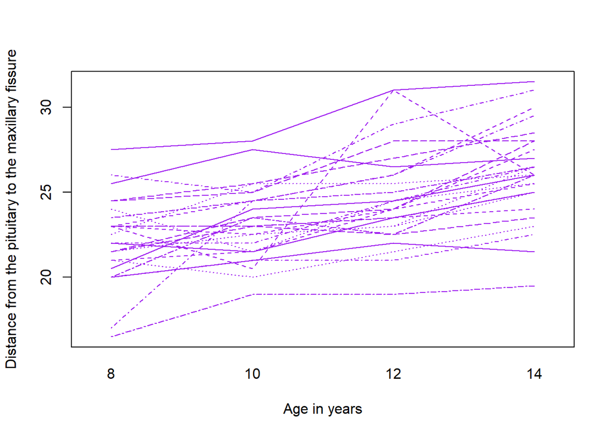

```r
n=length(unique(IDNR))
interaction.plot(AGE,IDNR,MEASURE, xlab="Age in years", ylab="Distance from the pituitary to the maxillary fissure",legend=F, col = "purple")
```

There is a general increase in dental growth with increasing age. Also, there is variation in dental growth among individuals within each age group regardless the increasing age.

Boxplots

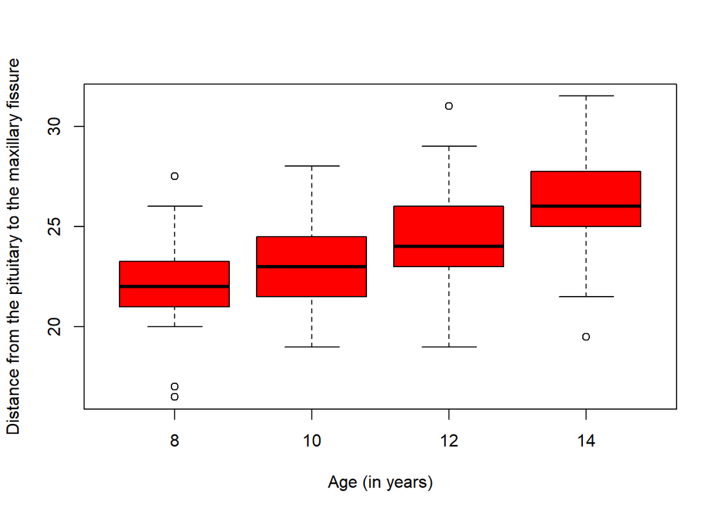

```r
boxplot(MEASURE~AGE,xlab="Age (in years)",ylab="Distance from the pituitary to the maxillary fissure", col = "red")
```

The boxplot show overall increase in distance from the center of the pituitary to the maxillary fissure as the individuals get older.  
Boxplots per gender

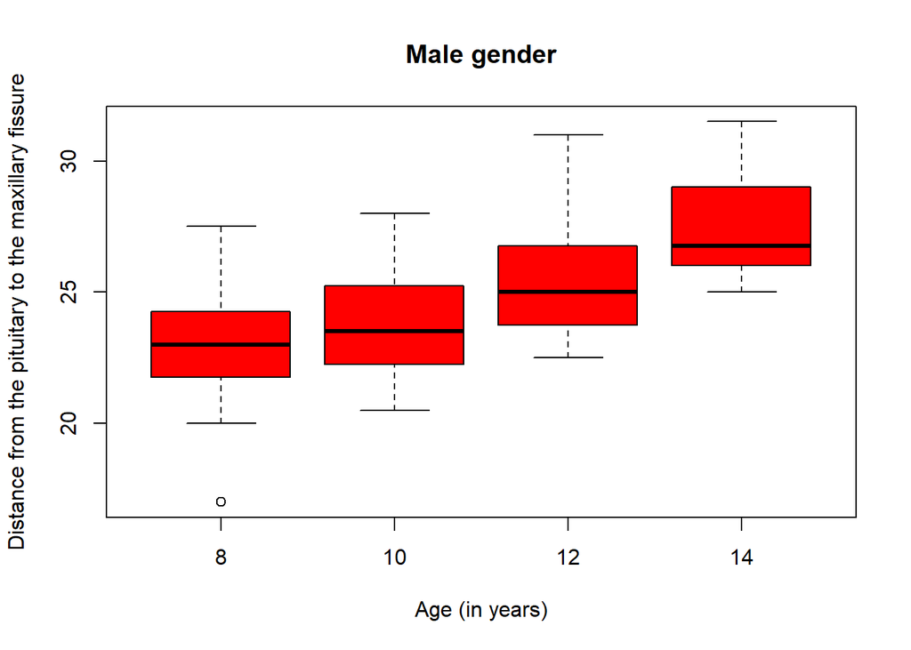

```r
boxplot(MEASURE[SEX==1]~AGE[SEX==1],main="Male gender",main="Male gender",xlab="Age (in years)",ylab="Distance from the pituitary to the maxillary fissure", col = "red")
```

Overall, there is increase in dental growth with increase in age in males

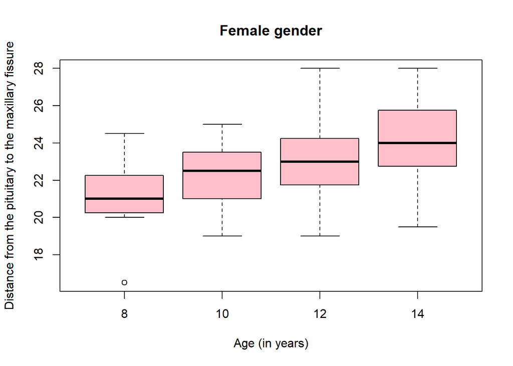

```r
boxplot(MEASURE[SEX==2]~AGE[SEX==2],main="Female gender", main="Female gender",xlab="Age (in years)",ylab="Distance from the pituitary to the maxillary fissure", col = "pink")
```

Overall, there is increase in dental growth with increase in age in females

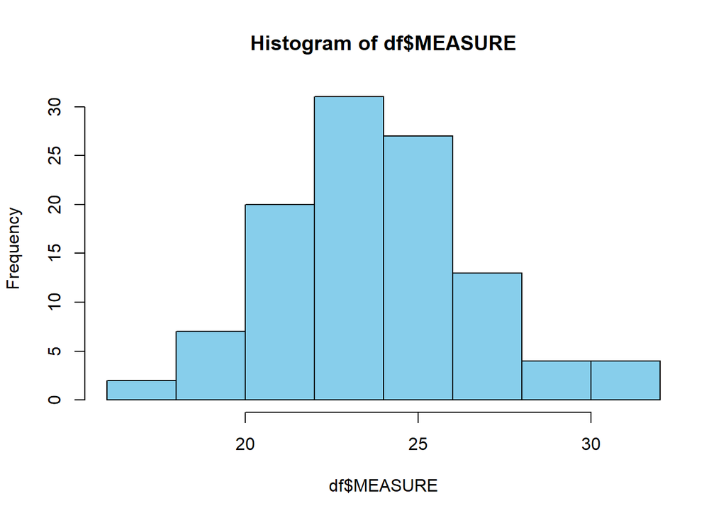

```r
hist(df$MEASURE, col="sky blue")
```

**Model fitting**

```r
df.lm <- lmer(MEASURE ~ SEX*AGE + (1 + AGE|IDNR), df, REML = FALSE)
summary(df.lm)
```

```
## Linear mixed model fit by maximum likelihood  ['lmerMod']
## Formula: MEASURE ~ SEX * AGE + (1 + AGE | IDNR)
##    Data: df
##
##      AIC      BIC   logLik deviance df.resid
##    443.8    465.3   -213.9    427.8      100
##
## Scaled residuals:
##     Min      1Q  Median      3Q     Max
## -3.3359 -0.4154  0.0104  0.4917  3.8582
##
## Random effects:
##  Groups   Name        Variance Std.Dev. Corr
##  IDNR     (Intercept) 4.55847  2.1351
##           AGE         0.02376  0.1542   -0.60
##  Residual             1.71615  1.3100
## Number of obs: 108, groups:  IDNR, 27
##
## Fixed effects:
##             Estimate Std. Error t value
## (Intercept)  15.3085     2.2891   6.688
## SEX           1.0321     1.5356   0.672
## AGE           1.0892     0.1933   5.636
## SEX:AGE      -0.3048     0.1297  -2.351
##
## Correlation of Fixed Effects:
##         (Intr) SEX    AGE
## SEX     -0.944
## AGE     -0.880  0.831
## SEX:AGE  0.831 -0.880 -0.944
```

```r
anova(df.lm)
```

|  | npar | Sum Sq | Mean Sq | F value |
| --- | --- | --- | --- | --- |
| SEX | 1 | 14.871370 | 14.871370 | 8.665523 |
| AGE | 1 | 184.310526 | 184.310526 | 107.397440 |
| SEX:AGE | 1 | 9.486759 | 9.486759 | 5.527919 |

Estimating fixed effect via bootstrap

```r
fixed.boot <- bootMer(df.lm, fixef, use.u=TRUE, nsim=250)
summary(fixed.boot)
```

|  | R | original | bootBias | bootSE | bootMed |
| --- | --- | --- | --- | --- | --- |
| (Intercept) | 250 | 15.3085227 | 0.18617613 | 1.8666022 | 15.3448625 |
| SEX | 250 | 1.0321023 | -0.09388251 | 1.2558890 | 0.9977970 |
| AGE | 250 | 1.0892045 | -0.01966940 | 0.1655413 | 1.0783169 |
| SEX:AGE | 250 | -0.3048295 | 0.01045831 | 0.1097606 | -0.2993962 |

Calculating confidence interval for the fixed effects

```r
confint(df.lm,method="boot",boot.type ="perc",oldNames = FALSE,nsim=500)
```

```
## Computing bootstrap confidence intervals ...
```

```
##
## 178 message(s): boundary (singular) fit: see ?isSingular
## 33 warning(s): Model failed to converge with max|grad| = 0.00209955 (tol = 0.002, component 1) (and others)
```

```
##                                 2.5 %      97.5 %
## sd_(Intercept)|IDNR       0.000000000  3.66036622
## cor_AGE.(Intercept)|IDNR -1.000000000  1.00000000
## sd_AGE|IDNR               0.006191333  0.30259543
## sigma                     1.044858030  1.52043058
## (Intercept)              11.264662307 19.62409991
## SEX                      -1.879800772  3.76496487
## AGE                       0.734570801  1.43654145
## SEX:AGE                  -0.525534766 -0.06159225
```

The estimates of the fixed effects fall within the confidence interval.

Get the KR-approximated degrees of freedom

```r
df.KR <- get_Lb_ddf(df.lm, fixef(df.lm))
early.lmer1.coef=coef(summary(df.lm))
early.lmer1.p.KR <- cbind(early.lmer1.coef,2 * (1 - pt(abs(early.lmer1.coef[,3]), df.KR)))
early.lmer1.p.KR
```

```
##               Estimate Std. Error    t value
## (Intercept) 15.3085227  2.2890730  6.6876516 2.410028e-07
## SEX          1.0321023  1.5355569  0.6721355 5.067953e-01
## AGE          1.0892045  0.1932725  5.6355909 4.285007e-06
## SEX:AGE     -0.3048295  0.1296511 -2.3511526 2.569284e-02
```

Age and gender significantly affects the distance from the center of the pituitary to the maxillary fissure.

Likelihoood ratio tests

```r
df.lm.null<-lmer(MEASURE ~ AGE + (1 + AGE|IDNR), df, REML = FALSE)
df.lm.treat<-lmer(MEASURE ~ SEX*AGE + (1 + AGE|IDNR), df, REML = FALSE)
anova(df.lm.null,df.lm.treat)
```

|  | npar | AIC | BIC | logLik | deviance | Chisq | Df | Pr(>Chisq) |
| --- | --- | --- | --- | --- | --- | --- | --- | --- |
| df.lm.null | 6 | 451.2116 | 467.3044 | -219.6058 | 439.2116 | NA | NA | NA |
| df.lm.treat | 8 | 443.8060 | 465.2630 | -213.9030 | 427.8060 | 11.40565 | 2 | 0.003336526 |

The model with the treatment is significant hence gender affects dental growth.

The mixed model is given as  
**MEASURE ~ AGE + SEX + SEX:AGE + (1 + AGE | IDNR) + e**.